Regresión Lineal Múltiple - Semana 07

Freddy Hernández

fhernanb@unal.edu.co

Profesor Asociado - Departamento de Estadística

Universidad Nacional de Colombia, Sede Medellín

1 / 33

Inferencias sobre la respuesta media y valores futuros

Suponga que se desea estimar la respuesta media para los valores en las predictoras

X1=x01,X2=x02,...,Xk=x0k.

Sea Y0la respuesta desconocida en tal conjunto de valores, si se deﬁne el vector ﬁla:

x0

= [

1x01 x02 . . . x0k

], entonces se puede escribir Y

0

=

x0β

+

ε0

,por lo tanto

la respuesta media en tal punto es:

µY|x0=E[Y|x0] = x0β=β0+β1x01 +β2x02 +··· +βkx0k.

Este valor es estimado por la correspondiente respuesta o valor ajustado,

b

Y0

, que puede

escribirse como:

b

Y0=x0b

β=b

β0+b

β1x01 +b

β2x02 +··· +b

βkx0k,

2 / 33

el cual tiene las siguientes propiedades:

▶Ehb

Y0i=Ehx0b

βi=x0Ehb

βi=x0β=E[Y|x0], esto es, b

Y0es un estimador

insesgado de la respuesta media E[Y|x0].

▶Var hb

Y0i=Var hx0b

βi=x0Var hb

βix′

0=σ2x0X′X−1x′

0, que es estimada por:

d

Var hb

Y0i=MSE x0X′X−1x′

0.

▶Bajo el supuesto de normalidad en los errores, b

Y0es una variable aleatoria normal,

debido a que es una combinación lineal de los b

βj’s que también son normales.

En resumen:

b

Y0∼NE[Y|x0], σ2x0X′X−1x′

0

3 / 33

[figure not shown]

Luego, se tiene que el estadístico T=b

Y0−E[Y|x0]

se(b

Y0)∼tn−p, con se(b

Y0) = qd

Var[b

Y0],

lo cual permite demostrar lo siguiente:

▶Para la respuesta media E[Y|x0]en un vector apropiado x0.

Pruebas de hipótesis sobre la respuesta media para un nivel de signiﬁcancia α

Juego de hipótesis Estadístico de prueba Criterio de rechazo

H0:µY|x0=c

H1:µY|x0=c

con c∈R

T0=b

Y0−c

se b

Y0bajo H0

∼tn−pSe rechaza H0si

|T0|>t1−α/2,n−p

donde t1−α/2,n−pes el percentil 1 −α/2 de la distribución t-Student con n−pgrados

de libertad.

4 / 33

[figure not shown]

IC del (1 −α)100% para la respuesta media E[Y|x0]:

Basados de nuevo en que el estadístico:

T=b

Y0−E[Y|x0]

se(b

Y0)∼tn−p

lo cual implica que:

P −tα/2,n−p<b

Y0−E[Y|x0]

se(b

Y0)<tα/2,n−p!=1−α

De donde se obtiene que un IC del (1 −α)100% para la respuesta media:

µY|x0=E[Y|x0]es:

b

y0±tα/2,n−pse(b

Y0).

5 / 33

Considere ahora el problema de predecir un valor futuro Y

0

(no observado en la muestra)

de la variable respuesta, en X1=x01,X2=x02,...,Xk=x0k.

Claramente, usando el modelo ajustado, predecimos de manera puntual tal valor por

b

Y0

,

pero sabemos que no es un estimador insesgado de Y

0

, por lo que siempre se genera un

error de predicción dado por: Y0−b

Y0.

Note que el error de predicción tiene media cero y dado que el valor futuro y su

pronóstico son independientes, entonces la varianza del error de predicción

b

Y0−

Y

0

está

dada por:

Var hY0−b

Y0i=Var [Y0] + Var hb

Y0i=σ2h1+x0X′X−1x0i,

que es estimada por: d

Var hb

Y0−Y0i=MSE h1+x0X′X−1x0i.

6 / 33

[figure not shown]

Con esto podemos hallar los siguientes resultados:

▶Para un valor futuro Y0en un vector apropiado x0:

IP del (1 −α)100% para un valor futuro Y0:

Basados en este caso en que el estadístico:

T=Y0−b

Y0

se(Y0−b

Y0)∼tn−p,

con se(Y0−b

Y0) = qd

Var[Y0−b

Y0], lo cual implica que:

P −tα/2,n−p<Y0−b

Y0

se(Y0−b

Y0)<tα/2,n−p!=1−α

De donde se obtiene que un IP del (1 −α)100% para un valor futuro Y0es:

b

Y0±tα/2,n−pse(Y0−b

Y0)

7 / 33

Notas:

▶

Los intervalos de predicción estiman los posibles valores para un valor particular de

la variable respuesta (no para su media) en un vector dado x0.

▶Asumimos que este valor particular es un valor futuro de la variable aleatoria Y, y

por tanto, no fue utilizado en la regresión.

▶Si Y0es un valor futuro y b

Y0=x0b

βes su estimador, entonces estas dos variables

aleatorias son estadísticamente independientes, dado que Y0no fue utilizado para

hallar los parámetros estimados, de ahí el estadístico y los límites del intervalo de

predicción.

8 / 33

Precaución:

Deben evitarse las extrapolaciones por fuera del rango de experimentación en el espacio

de las predictoras, para lo cual no basta con evaluar si cada valor componente del vector

x0

se encuentra dentro del rango usado (u observado) para la correspondiente predictora,

sino que es necesario evaluar si x0pertenece a la región de observación conjunta.

Para ello basta con veriﬁcar si:

h00 =x0X′X−1x′

0<max

1≤i≤n{hii }

con hii el i-ésimo elemento de la matriz ‘hat’ H

n×n=X(XTX)−1XT.

9 / 33

Validación de los supuestos del modelo de RLM

Para la validación de supuestos se usan generalmente los residuales del modelo, los

cuales sabemos que se deﬁnen así:

ei=yi−ˆyi,i=1,...,n

Observe que, la magnitud de los residuales eidepende de la escala de medida de la

respuesta Y, lo cual no permite determinar cuando un residual es ‘grande’. Para resolver

este problema en lugar de usar los residuales crudos deﬁnidos arriba, se recomienda

utilizar residuales escalados que transforman a los anteriores para tener media cero y

varianza unitaria.

10 / 33

Residuales escalados

Se han deﬁnido varias versiones de residuales escalados, entre los que se destacan:

▶Residuales estandarizados: para su deﬁnición se considera el supuesto sobre los

errores, que establece que

εi

se distribuye con media cero y varianza

σ2

. Por tanto,

los residuales estandarizados, denotados dise deﬁnen como:

di=ei

√MSE,i=1,...,n

Si el supuesto es adecuado los valores de d

i

deben oscilar entre -3 y 3. Por tanto, Un d

i

grande (|di|>3) es indicio de una observación potencialmente atípica.

11 / 33

▶Residuales estudentizados: para su deﬁnición se considera el hecho de que

realmente los residuales eien general no son independientes ni tienen varianza

constante como los errores εi. Veamos,

Sabemos que,

e

= (

I−H

)

Y

, donde

I−H

es una matriz simétrica e idempotente.

Luego,

E[e] = E[(I−H)Y]=(I−H)E[Y]=(I−H)Xβ

=Xβ−HXβ=Xβ−XX′X−1X′Xβ=0

Var [e] = Var [(I−H)Y]=(I−H)Var [Y] (I−H)′=σ2(I−H)

De donde: V(ei) = σ2(1−hii )y cov(ei,ej) = −σ2hij .

12 / 33

Por tanto, mientras que los errores εitienen varianza constante σ2y son

incorrelacionados, los residuales no necesariamente tienen la misma varianza y pueden

ser correlacionados.

De esta forma, los residuales estudentizados, denotados ri, se deﬁnen como:

ri=ei

pMSE(1−hii ),i=1,...,n.

Este residual, con mayor razón debe moverse entre -3 y 3. Se considera atípica aquella

observación con un rigrande (|ri|>3).

13 / 33

NOTAS:

▶Si el modelo de RLM especiﬁcado es correcto los ritienen varianza

aproximadamente constante!! igual a 1.

▶En conjuntos grandes de datos la varianza de los rise puede estabilizar en 1 y así

no habrá mucha diferencia entre éstos y los di.

▶Si todos los supuestos del modelo se cumplen, se espera que aproximadamente el

68% de los residuales d

i

ór

i

, estén entre

−

1 y +1, aproximadamente el 95% entre

−2 y +2 y aproximadamente 99.7% entre −3 y +3.

La validación de los supuestos vista en regresión lineal simple se mantiene, solo que

ahora se recomienda utilizar residuales escalados (dió preferiblemente ri) en lugar de

utilizar los residuales crudos ei.

14 / 33

Validación de los supuestos en los errores

Recuerde que en los modelos de regresión se han impuesto las siguientes cuatro

condiciones sobre el término de error:

▶Los errores son variables aleatorias normales.

▶Los errores tienen media cero.

▶Los errores tienen varianza constante.

▶Los errores son mutuamente independientes.

15 / 33

Recuerde que en esta asignatura asumiremos el supuesto de independencia de los errores

y en virtud de que usando los residuales del modelo el supuesto de media cero siempre se

cumple, entonces se deﬁne lo siguiente:

▶

El supuesto de normalidad puede chequearse bien sea con el gráﬁco de probabilidad

normal de los residuales o con alguna de las pruebas analíticas de normalidad, entre

las cuales se tienen las de Shapiro Wilk, Kolmogorov Smirnov, Cramér von Mises y

Anderson Darling.

▶Para chequear el supuesto de varianza constante, resulta útil un gráﬁco de

residuales versus valores ajustados de la respuesta.

16 / 33

Falta de ajuste en el modelo de RLM

La falta de ajuste también puede ser evaluada y para el modelo de regresión múltiple se

quiere saber si:

EYX1,X2,...,Xk=β0+β1X1+β2X2+··· +βkXk,

es una superﬁcie de respuesta apropiada, es decir, se quiere probar:

H0:EYX1,X2,...,Xk=β0+β1X1+β2X2+··· +βkXk

H1:EYX1,X2,...,Xk=β0+β1X1+β2X2+··· +βkXk

Para llevar a cabo esta prueba, se necesitan replicaciones de la respuesta en las

combinaciones de niveles de las variables predictoras. El procedimiento es el mismo que

se estudió en RLS y se basa en la descompocisión de la SSE:

SSE =SSLOF +SSPE

17 / 33

[figure not shown]

El procedimiento de prueba se resume en la siguiente tabla:

ANOVA con prueba de falta de ajuste en el modelo de RLM

Fuente de Suma de Grados de Cuadrado F

Variación Cuadrados Libertad Medio Calculado

Regresión SSR k =p−1MSR =SSR

k=SSR F0=MSR

MSE

Error SSE n−p MSE =SSE

n−p

Falta de Ajuste SSLOF m −p MSLOF =SSLOF

m−pF0=MSLOF

MSPE

Error Puro SSPE n −m MSPE =SSPE

n−m

Total SST n −1

Se rechaza H0a un nivel de signiﬁcancia αsi F0>f1−α;m−p,n−m. En tal caso se

concluye que la superﬁcie de respuesta no es apropiada.

18 / 33

Medidas Remediales

Las medidas remediales descritas en el caso de RLS también son aplicables en RLM. Con

el ﬁn de superar las deﬁciencias del modelo se pueden realizar transformaciones sobre la

variable respuesta y/o sobre las variables predictoras.

Las transformaciones sobre la respuesta pueden ayudar en el caso de que los errores no

resulten normales o la varianza no sea constante. Transformaciones sobre las variables

predictoras resultan útiles cuando la superﬁcie de respuesta es curvilínea.

Si las desviaciones respecto al supuesto de normalidad son severas, y ninguna

transformación resulta útil y/o interpretable, existe otra alternativa, los llamados

modelos lineales generalizados con los cuales se pueden modelar respuestas que no se

distribuyen normales; sin embargo, tales modelos están más allá del alcance de este

curso.

19 / 33

Identiﬁcación de observaciones extremas en el modelo de RLM

Además de la validación de supuestos en los errores de un modelo de RLM, se debe

chequear la presencia de observaciones extremas, tales como:

▶Observaciones atípicas (outliers)

▶Puntos de balanceo

▶Observaciones inﬂuenciales

20 / 33

Observaciones atípicas

Una observación atípica (o outlier) es aquella que está separada (en su valor de la

respuesta Y) del resto de las observaciones y por tanto puede afectar los resultados del

ajuste del modelo de regresión.

Interesa identiﬁcarlas para luego, si es posible analizar si se tratan de observaciones

malas (por errores de registro o medición) que pueden ser descartadas, o si realmente

son datos correctos pero extraños que no deben ser eliminados del conjunto de datos.

Para detectar observaciones atípicas se usan los residuales escalados deﬁnidos

anteriormente. Se considera que una observación es atípica cuando su residual

estudentizado ri, es tal que: |ri|>3.

Muchos outliers en los datos pueden causar niveles de conﬁanza reales menores de lo

esperado.

21 / 33

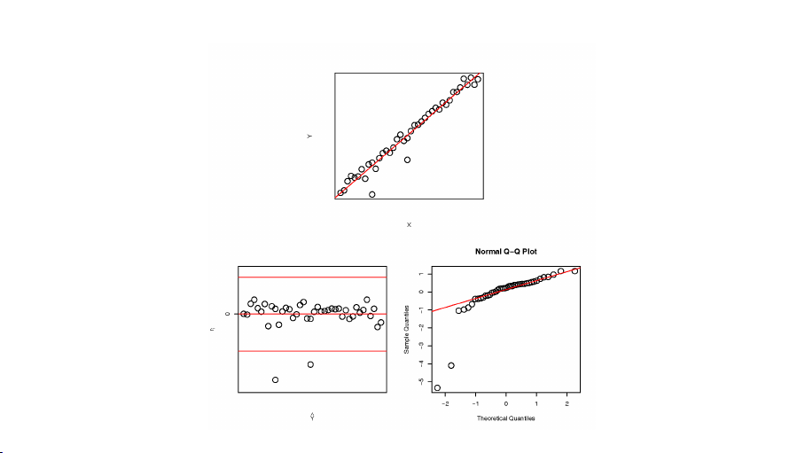

La siguiente ﬁgura ilustra el caso de dos observaciones atípicas.

22 / 33

Puntos de balanceo

Un punto de balanceo es una observación en el espacio de las predictoras, alejada del

resto de la muestra y que puede controlar ciertas propiedades del modelo ajustado.

Este tipo de observaciones posiblemente no afecte los coeﬁcientes de regresión

estimados pero sí las estadísticas de resumen como el R2y los errores estándar de los

coeﬁcientes estimados.

Los puntos de balanceo son detectados mediante el análisis de los elementos de la

diagonal principal de la matriz

H

, los h

ii

, que proporcionan una medida estandarizada de

la distancia de la i-ésima observación al centro del espacio deﬁnido por las predictoras.

23 / 33

Se tiene lo siguiente:

▶La media de los hii es:

¯

h=

n

P

i=1

hii

n=traza (H)

n=p

n

con pel número de parámetros del modelo de RLM.

▶Se asume que la observación ies un punto de balanceo si hii >2p/n, pero si

2p/n>1 este criterio no funciona pues los hii siempre son menores que 1.

▶

Observaciones con h

ii

grandes y residuales r

i

también grandes, probablemente serán

inﬂuenciales.

24 / 33

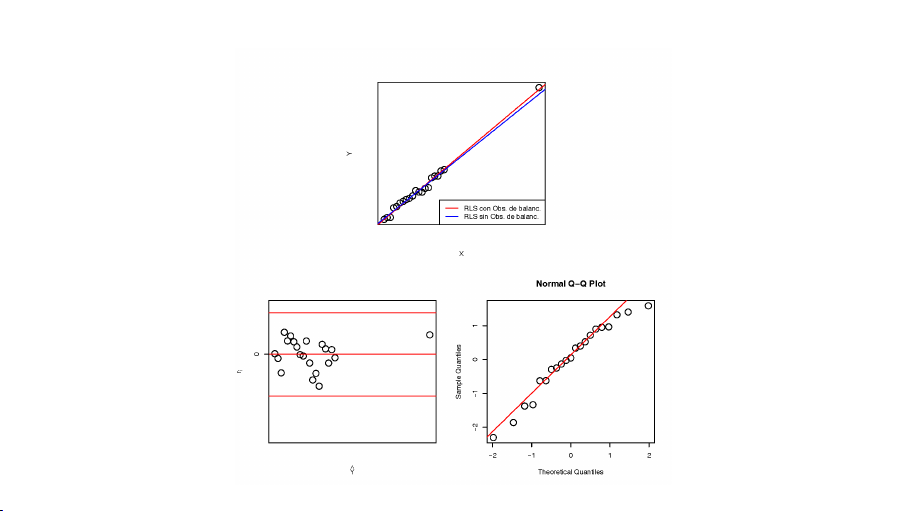

La próxima ﬁgura ilustra el caso de una observación de balanceo.

25 / 33

Observaciones inﬂuenciales

Una observación es inﬂuencial si tiene un impacto notable sobre los coeﬁcientes de

regresión ajustados, esto es, una observación inﬂuencial se dice que hala al modelo en su

dirección, es decir, una observación es inﬂuencial si su exclusión del modelo causa

cambios importantes en la ecuación de regresión ajustada.

Estas observaciones se caracterizan por tener un valor moderadamente inusual tanto en

el espacio de las predictoras como en la respuesta.

Después de identiﬁcar las observaciones que están alejadas con respecto a los valores de

Y(atípicas) y/o con respecto a sus valores en X(puntos de balanceo) evaluamos si

éstas son inﬂuenciales.

26 / 33

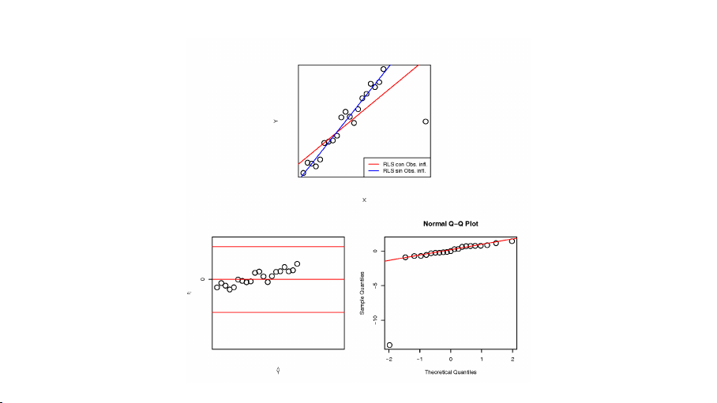

La ﬁgura siguiente ilustra el caso de una observación inﬂuyente

27 / 33

Para la evaluación se cuenta con las siguientes medidas:

▶Distancia de Cook.

▶Diagnóstico DFFITS.

▶Diagnóstico DFBETAS.

A continuación se presentan los diagnósticos para detectar observaciones inﬂuenciales.

28 / 33

1. Distancia de Cook: es una medida de la distancia cuadrática entre, el estimador

de βpor mínimos cuadrados basado en las nobservaciones, y el estimador de β

obtenido eliminando la i-ésima observación, así:

Di=b

β(i)−b

β′X′Xb

β(i)−b

β

pMSE =r2

i

phii

1−hii ,i=1,...,n

donde, b

β(i)es el vector de parámetros estimados obtenido cuando no se considera

en el ajuste del modelo a la observación i.

Note que si Dies alto entonces la observación itiene inﬂuencia sobre el vector de

parámetros estimados b

β.

29 / 33

NOTAS:

▶

Si D

i

=f

0.5;p,n−p

entonces, al eliminar el punto ise movería

b

β(i)

hacia la frontera

de una región de conﬁanza aproximada del 50% para β, basándose en el conjunto

completo de datos, lo cual es un desplazamiento grande e indica que el estimador

por mínimos cuadrados es sensible al i-ésimo punto de datos.

▶Como f0.5,p,n−p≈1se dice que la observación iserá inﬂuencial si Di>1.

30 / 33

2.

Diagnóstico DFFITS: es el número de desviaciones estándar que el valor ajustado

b

yise mueve si la observación ies omitida:

DFFITSi=b

Yi−b

Y(i)

qMSE(i)hii

=ei

qMSE(i)(1−hii )hii

1−hii 1/2

donde, b

Y(i)es el i-ésimo valor ajustado obtenido cuando no se considera en el

ajuste del modelo a la observación iy MSE(i)es el cuadrado medio del error

obtenido cuando no se considera en el ajuste del modelo a la observación i.

Una observación será inﬂuencial si |DFFITSi|>2qp

n.

31 / 33

3.

Diagnóstico DFBETAS: indica cuánto cambia el j-ésimo coeﬁciente de regresión

estimado

b

βj

en unidades de desviación estándar, si se omite la i-ésima observación:

DFBETASj(i)=b

βj−b

βj(i)

qMSE(i)cjj

donde cjj es el j-ésimo elemento en la diagonal principal de la matriz: (X′X)−1y

MSE(i)es el MSE de la regresión sin la observación i.

Una observación será inﬂuencial si |DFBETASj(i)|>2/√n.

32 / 33

NOTA: Tanto los D

i

, como los DFFITS y los DFBETAS se pueden afectar tanto por un

error de ajuste grande como por un gran balanceo, por eso, los puntos que sean

detectados por estos criterios deben ser investigados.

33 / 33